# Houston Crime Analysis

Krishna Prasad

16 August, 2019

# 1 Problem Description and Objectives

[Houston Police Department](https://www.houstontx.gov) provide data with information on crime events at different locations of the city of Houston, Texas. Using data available at [Houston Police Department Crime Statistics](https://www.houstontx.gov/police/cs/Monthly_Crime_Data_by_Street_and_Police_Beat.htm), our objective is to import the data into R to carry out exploratory data analysis and provide some useful insights to the police department.

The information contained in these reports is a monthly breakdown of all the offenses in Houston city. The data is broken down by police districts and beats, and displayed by street name and block range.

# 2 Data Description

The main data source provided by the Houston Police Department is integrated with two other data sources [Offenses mapping](https://ucr.fbi.gov/nibrs/2011/resources/nibrs-offense-codes/view) and the zip codes package available in R help in analyzing the crime statics better.

- The offenses mapping provide higher level information about who/how/where the crime happened against. Below are few examples which illustrates what the data set provides:
  - If nibrs description is related to theft then the crime is against property
  - If nibrs description is related to assaults then the crime is against a person
  - If nibrs description is related to drugs then the crime is against society
- The zip code data provides information on latitudes and longitudes for uses in mapping data.

# 3 Data Pre-Processing

- Downloaded all the files from [Houston Police Department Crime Statistics](https://www.houstontx.gov/police/cs/Monthly_Crime_Data_by_Street_and_Police_Beat.htm) website and save it locally.

```r
#
# Downloads the data from the website and places all the files in the data directory in the current location
# Returns the list of all files downloded
#
download_files <- function(filename) {

  files_count = 1

  # Check if data directory exists else create one
  if (!dir.exists(data_directory))
    dir.create(data_directory)

  # Download each file in the filename vector
  for (nibrs_file in filename) {
    # Set files path
    nibrs_xls_file <-
      paste(data_directory, "/", nibrs_file, sep = "")

    # Download file
    download.file(paste(uri, nibrs_file, sep = ""), nibrs_xls_file, method = "curl")

    # Set a new file name for the downloaded file
    new_file_name <-
      paste0(data_directory, "/", files_count, "-2019", sep = "")

    # Rename file
    file.rename(nibrs_xls_file,
                paste(new_file_name, ".xlsx", sep = ""))

    files_count = files_count + 1
  }

  # List all the files in the data directory
  all_files <-
    list.files(path = data_directory,
               pattern = ".xlsx",
               full.names = TRUE)
  return(all_files)
}
```

- Consolidated all the files by removing all irrelevant rows and columns from the data sets

```r
#
# Removes all the irrelavent columns, Consolidates all the files and returns a data frame
#
consolidate_data <- function(all_files) {

  counter <- 0

  # For each file in the data directory
  for (item in all_files) {
    # Read the file by skipping the first 11 rows in each file
    my_data <-
      readxl::read_excel(item,
                         skip = 11,
                         col_names = TRUE,
                         na = "NA")

    # After removing the first 11 lines, in Apr and May files there are 11 valid columns
    # and Jan, Feb, Mar have only 10 valid columns
    # Hence the invalid columns are at different indexes which needs to be removed
    # THIS PART NEEDS TO BE HANDLED BETTER
    if (grepl("4-2019", item) | grepl("5-2019", item)) {
      my_data <- my_data[-c(2, 5, 6, 11, 13, 14, 17)]
    }
    else{
      my_data <- my_data[-c(2, 4, 6, 11, 13, 14, 16)]
    }

    if (counter == 0) {
      consolidated_data <- my_data
    }
    else {
      # fill in non-overlapping columns with NAs as there are 11 columns for Apr, May and 10 for other months
      consolidated_data[setdiff(names(my_data), names(consolidated_data))] <- NA
      my_data[setdiff(names(consolidated_data), names(my_data))] <- NA

      # Bind data for all the months
      consolidated_data <- rbind(consolidated_data, my_data)
    }
    rm(my_data)
    counter = counter + 1
  }
  # Write consolidated data to xlsx file
  write.xlsx(consolidated_data,
             paste(data_directory, "/", "2019.xlsx", sep = ""))

  return(consolidated_data)
}
```

- Offenses mapping and zip codes packages are joined to the Houston data set to help with binning of offense descriptions.

```r
#
# Join the Offenses mapping file, Rename, separate and reorder columns
# Returns the new dataframe
#

reorder_clean <- function(consolidated_data) {

    # Read the consolidated xlsx file
    crime_data <- consolidated_data

    # Read the Offense Mapping file
    offense_map <-
      readxl::read_excel(
        paste(".", "/", "offenses_mapping.xlsx", sep = ""),
        col_names = TRUE,
        trim_ws = TRUE
      )

    # Rename the columns consistently into lowercase and without spaces
    crime_data <-
      crime_data %>% rename_all(funs(str_replace(., " ", "_"))) %>% rename_all(tolower)

    # Separate the Block range column
    crime_data <-
      separate(crime_data,
               block_range,
               into = as.character(c("block_start", "block_end")),
               sep = "-")

    # Join with offense list to add the crime against column into the dataset
    crime_data <-
      inner_join(crime_data, offense_map, by = "nibrs_description")


    return(crime_data)
}
```

- Using the zip code information available for Apr and May along with the blocks, street and beat information, all the NA values are filled for beats, blocks and zips using **KNN imputation technique**.

```r
#
# Impute Beat, Blocks and zip values using KNN imputations, Saves the new file in the current location
# Returns the modified dataframe with all the imputed values
#

fill_values_using_knn <- function(crime_data) {
  # Convert beat, block_start, block_end, zip into factors
  crime_factors <- c("beat", "block_start", "block_end", "zip")
  crime_data[crime_factors] <-
    sapply(crime_data[crime_factors], as.factor)

  # Perform KNN imputations on the above columns to fill in NA values
  crime_data_imputed <-
    kNN(
      crime_data,
      variable = c("beat", "block_start", "block_end", "zip"),
      dist_var = c(
        "beat",
        "block_start",
        "block_end",
        "street_name",
        "street_type",
        "suffix",
        "zip"
      ),
      k = 5,
      trace = FALSE
    )

  # Remove the extra trace columns
  crime_data_imputed <- crime_data_imputed[-c(18, 19, 20, 21)]

  # Join with zipcodes to add the latitude and longitude column into the dataset
  crime_data_imputed <- crime_data_imputed %>%
    inner_join(select(zipcode, zip, latitude, longitude), by = "zip")

  # Write imputed crime data to xlsx file
  write.xlsx(crime_data_imputed,
             paste(data_directory, "/", "2019_Imputed_New.xlsx", sep = ""))

  # copy file to current folder
  file.copy(paste(data_directory, "/", "2019_Imputed_New.xlsx", sep = ""), ".")

  return(crime_data_imputed)
}
```

- Variables in the data set can be categorized into quantitative and categorical variables. Below is some important information on the data types of the variables and their significance:
  - `occurrence_date` - Date column representing the year, month and day the incident happened.
  - `occurrence_hour` - Nominal/categorical variables describing the hour of the day the incident occured.
  - `nibrs_description` - Nominal/categorical(label) varible describing the incident
  - `offense_count` - Quantitative variable describing the count of charges for that incident
  - `beat` - Nominal/categorical(label) variable specifying in which beat the incident occured.
  - `premise` - Nominal/categorical(label) variable describing where the indicident occured
  - `block start/end` - Nominal/categorical variable specifying in which block ranges the incident occured
  - `street_name/street_type/suffix` - Nominal/categorical variable specifying in which streets the incident occured
  - `zip` - Nominal/categorical variables specifying in which zipcode incident occured
- The occurrence_date is extrapolated into `occurrence_day, occurrence_month, occurrence_weekday, occurrence_weekday_num`

```
## Observations: 101,642
## Variables: 19
## $ occurrence_date        <date> 2019-01-01, 2019-01-01, 2019-01-01, 2019…
## $ occurrence_weekday_num <fct> 3, 3, 3, 3, 3, 3, 3, 3, 3, 3, 3, 3, 3, 3,…
## $ occurrence_weekday     <fct> Tuesday, Tuesday, Tuesday, Tuesday, Tuesd…
## $ occurrence_year        <dbl> 2019, 2019, 2019, 2019, 2019, 2019, 2019,…
## $ occurrence_month       <fct> 1, 1, 1, 1, 1, 1, 1, 1, 1, 1, 1, 1, 1, 1,…
## $ occurrence_hour        <chr> "00", "00", "00", "00", "00", "00", "00",…
## $ nibrs_description      <chr> "Destruction, damage, vandalism", "Drug, …
## $ crime_against          <chr> "Property", "Society", "Society", "Proper…
## $ offense_count          <dbl> 1, 1, 1, 1, 1, 1, 1, 1, 1, 1, 1, 1, 1, 1,…
## $ beat                   <fct> 9C30, 7C10, 7C10, 16E40, 2A60, 2A60, 15E3…
## $ premise                <chr> "Residence, Home (Includes Apartment)", "…
## $ block_start            <fct> 9600, 1900, 1900, 16700, 1900, 1900, 4000…
## $ block_end              <fct> 9699, 1999, 1999, 16799, 1999, 1999, 4099…
## $ street_name            <chr> "SAN CARLOS", "EAST", "EAST", "LONE QUAIL…
## $ street_type            <chr> NA, "FWY", "FWY", "CT", NA, NA, "DR", "DR…
## $ suffix                 <chr> NA, NA, NA, NA, NA, NA, NA, NA, NA, NA, N…
## $ zip                    <fct> 77088, 77055, 77055, 77489, 77055, 77055,…
## $ latitude               <dbl> 29.87921, 29.79888, 29.79888, 29.60114, 2…
## $ longitude              <dbl> -95.45028, -95.49629, -95.49629, -95.5177…
```

# 4 Exploratory Data Analysis

Data summaries try to provide overviews of key properties of the data. More specifically, they try to describe important properties of the distribution of the values across the observations in a data set.

## 4.1 Summary of Houston Crime Data

```r
summary(crime_data)
```

```
##  occurrence_date      occurrence_weekday_num occurrence_weekday
##  Min.   :2019-01-01   1:13516                Friday   :14905
##  1st Qu.:2019-02-09   2:13979                Monday   :13979
##  Median :2019-03-20   3:14545                Saturday :14595
##  Mean   :2019-03-18   4:15196                Sunday   :13516
##  3rd Qu.:2019-04-26   5:14906                Thursday :14906
##  Max.   :2019-05-30   6:14905                Tuesday  :14545
##                       7:14595                Wednesday:15196
##  occurrence_year occurrence_month occurrence_hour    nibrs_description
##  Min.   :2019    1:19879          Length:101642      Length:101642
##  1st Qu.:2019    2:18486          Class :character   Class :character
##  Median :2019    3:20255          Mode  :character   Mode  :character
##  Mean   :2019    4:20923
##  3rd Qu.:2019    5:22099
##  Max.   :2019
##
##  crime_against      offense_count         beat         premise
##  Length:101642      Min.   : 0.000   17E10  : 2090   Length:101642
##  Class :character   1st Qu.: 1.000   14D20  : 2038   Class :character
##  Mode  :character   Median : 1.000   15E40  : 1972   Mode  :character
##                     Mean   : 1.032   22B20  : 1959
##                     3rd Qu.: 1.000   19G10  : 1945
##                     Max.   :10.000   1A10   : 1868
##                                      (Other):89770
##   block_start      block_end     street_name        street_type
##  900    : 1330   999    : 1330   Length:101642      Length:101642
##  4400   : 1322   4499   : 1322   Class :character   Class :character
##  100    : 1228   199    : 1228   Mode  :character   Mode  :character
##  1900   : 1140   1999   : 1140
##  2500   : 1113   2599   : 1113
##  2400   : 1100   2499   : 1100
##  (Other):94409   (Other):94409
##     suffix               zip           latitude       longitude
##  Length:101642      77004  : 3629   Min.   :28.98   Min.   :-97.68
##  Class :character   77036  : 3347   1st Qu.:29.69   1st Qu.:-95.50
##  Mode  :character   77026  : 2953   Median :29.74   Median :-95.40
##                     77060  : 2821   Mean   :29.75   Mean   :-95.42
##                     77042  : 2559   3rd Qu.:29.80   3rd Qu.:-95.34
##                     77061  : 2418   Max.   :30.45   Max.   :-94.94
##                     (Other):83915
```

## 4.2 Data Visualizations

### 4.2.1 Total count of offenses month over month

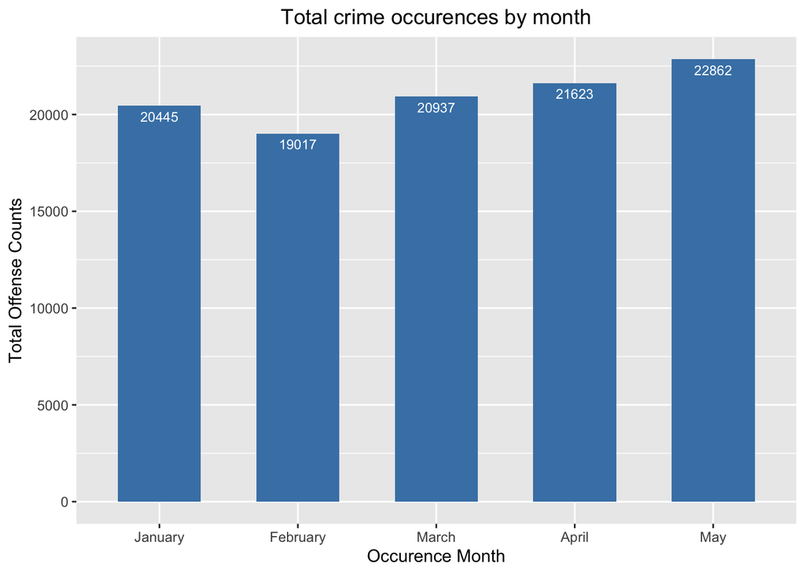

```r
# Group by month and sum of offense counts
crime_monthly <-
  group_by(crime_data,
           OccurenceMonths = format(crime_data$occurrence_date, "%B")) %>%  dplyr::summarize(Count = sum(offense_count))

# Create a Bar plot using the crime_monthly dataframe
ggplot(crime_monthly, aes(
  x = factor(OccurenceMonths, levels = month.name),
  y = Count,
  fill = OccurenceMonths
)) +
  geom_bar(stat = "identity", width = 0.6, fill = "steelblue") +
  geom_text(aes(label = Count),
            vjust = 1.6,
            color = "white",
            size = 3) +
  theme(legend.position = "none", plot.title = element_text(hjust = 0.5)) +
  labs(title = "Total crime occurences by month",
       x = "Occurence Month", y = "Total Offense Counts")
```

- The above graph shows the total monthly count (Jan-May’19) of all the crimes in the city of Houston.
- The monthly crime in the city of Houston has been steadily increasing, with the exception of February-which saw a dip in the total count of crime occurrences.

### 4.2.2 Total count of offenses by day of a week

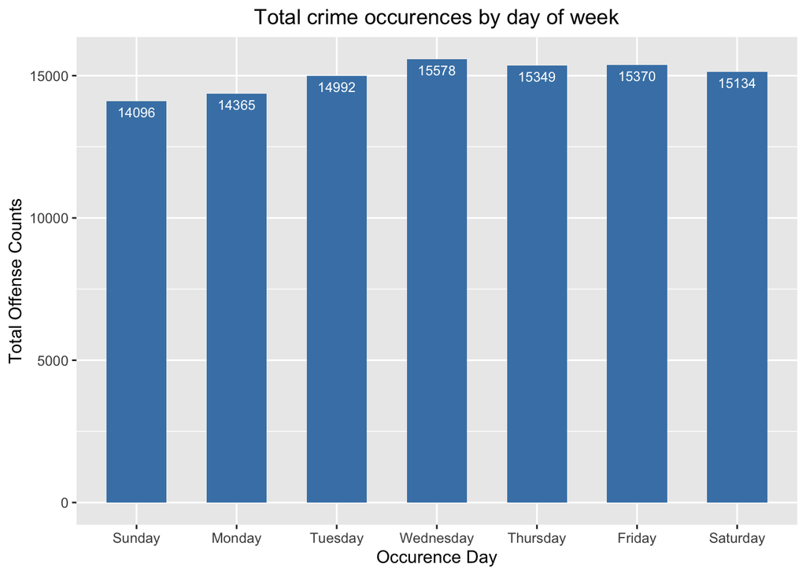

```r
# Group by weekday ans summarize by adding up all the offense counts
crime_week <-
  group_by(
    crime_data,
    DayOccurence = as.factor(occurrence_weekday)
  ) %>% dplyr::summarize(Count = sum(offense_count))


# Craete a Bar plot
ggplot(crime_week, aes(
  x = factor(
    DayOccurence,
    levels = c(
      "Sunday",
      "Monday",
      "Tuesday",
      "Wednesday",
      "Thursday",
      "Friday",
      "Saturday"
    )
  ),
  y = Count
))  +
  geom_bar(stat = "identity", width = 0.6, fill = "steelblue") +
    geom_text(aes(label = Count),
            vjust = 1.6,
            color = "white",
            size = 3) +
  theme(legend.position = "none", plot.title = element_text(hjust = 0.5)) +
  labs(title = "Total crime occurences by day of week",
       x = "Occurence Day", y = "Total Offense Counts")
```

- Interestingly mid of the week has the highest crime count in the city of Houston.
- Fridays has a higher total offense count.

### 4.2.3 Total count of offenses by hour of a day

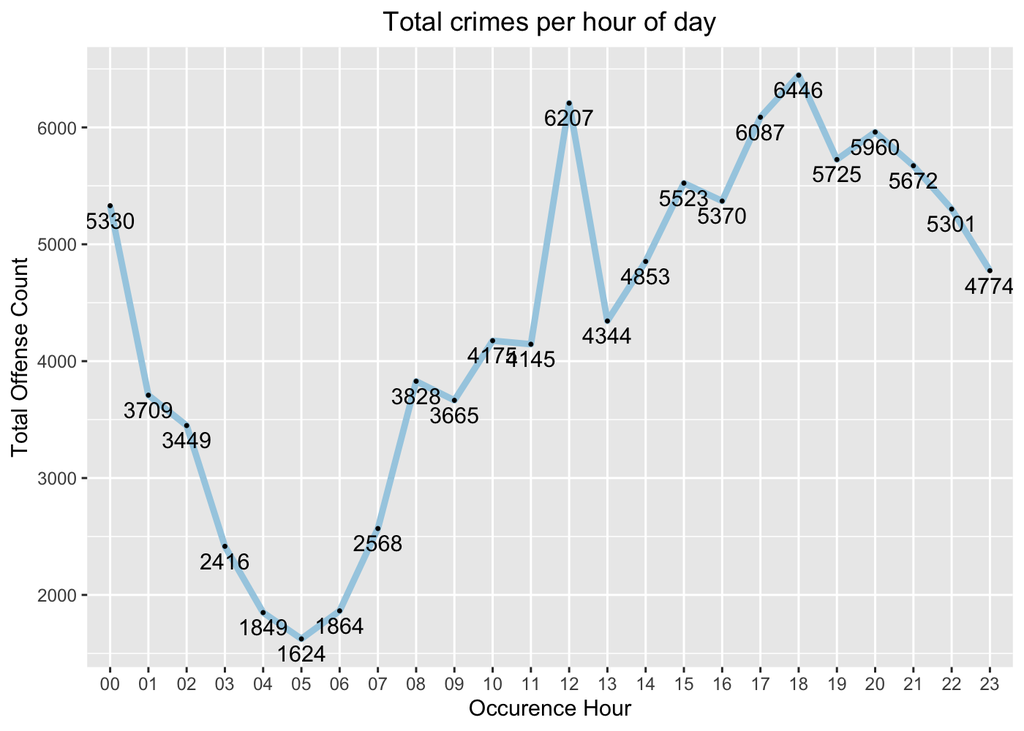

```r
# Group crime data by hour of day
crime_hr <-
  group_by(
    crime_data,
    OccurenceHour = as.factor(occurrence_hour)
  ) %>%  dplyr::summarize(Count = sum(offense_count)) %>% arrange( OccurenceHour)

# Plot a line graph
ggplot(data = crime_hr, aes(x = OccurenceHour,
                            y = Count,
                            group = 1)) +
  geom_line(aes(color = "blue"), size = 1.5) +
  geom_point(size = 0.5) +
  theme(legend.position = "none",
        plot.title = element_text(hjust = 0.5)) +
  geom_text(aes(label = Count), hjust = .5, vjust = 1.4) +
  scale_color_brewer(palette = "Paired") +
  labs(title = "Total crimes per hour of day", x = "Occurence Hour", y = "Total Offense Count")
```

- Noon and 6PM of the day are seem to be the times of the day when the highest offenses happen. It is possible that too many thefts could increase the offense count in the mid day.

### 4.2.4 Offenses distribution by month

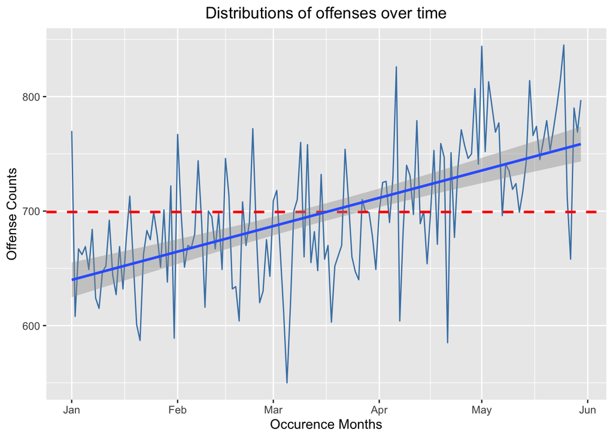

```r
# Select Occurrence Data and offense count Group by date
offense_dist <-
  crime_data %>% dplyr::select(occurrence_date, offense_count) %>% group_by(occurrence_date) %>%
  summarise(Count = sum(offense_count))

# Plot a time series graph showing the distribution of offenses over 5 months period
ggplot(offense_dist,
       aes(x = offense_dist$occurrence_date, y = offense_dist$Count)) +
  geom_line(color = "steelblue") +
  geom_hline(
    aes(yintercept = mean(offense_dist$Count)),
    color = "red",
    linetype = "dashed",
    size = 1
  ) +
  geom_smooth(method = 'lm') +
  theme(legend.position = "none",
        plot.title = element_text(hjust = 0.5)) +
  scale_color_brewer(palette = "Paired") +
  labs(title = "Distributions of offenses over time", x = "Occurence Months", y = "Offense Counts")
```

### 4.2.5 Top 10 crimes in Houston

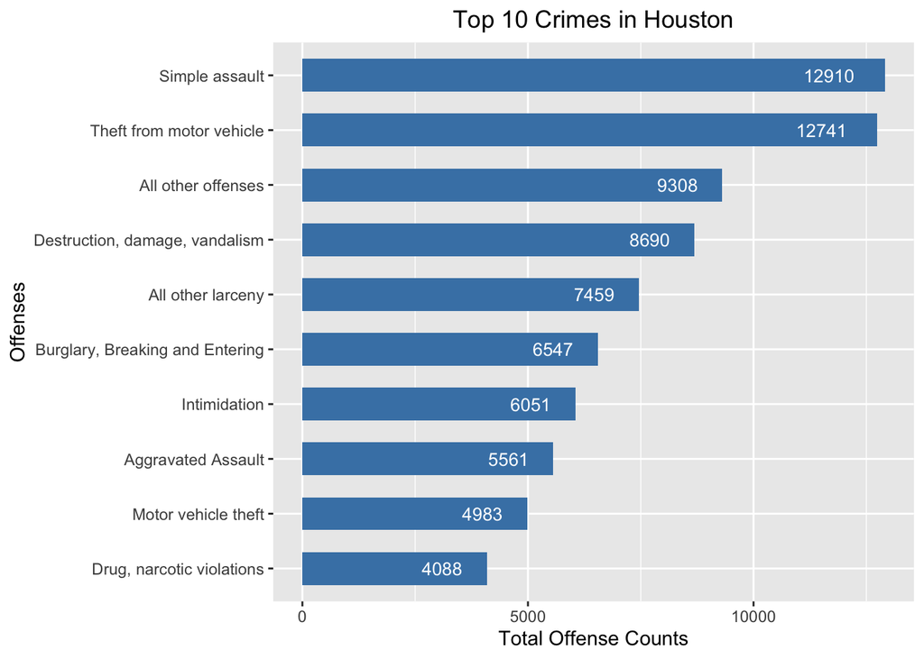

```r
# Group by offense description
top_crimes <-
  group_by(
    crime_data,
    Offenses = nibrs_description
  ) %>%  dplyr::summarize(Count = sum(offense_count)) %>%  arrange( desc(Count)) %>%
  top_n(10)


# Horizontal Bar plot
ggplot(top_crimes, aes(
  x = reorder(Offenses, Count),
  y = Count,
  fill = Offenses
)) +
  geom_bar(stat = "identity", width = 0.6, fill = "steelblue") +
  coord_flip() +
  geom_text(aes(label = Count),
            hjust = 1.6,
            color = "white",
            size = 3.5) +
  theme(legend.position = "none",
        plot.title = element_text(hjust = 0.5)) +
  labs(title = "Top 10 Crimes in Houston",
       x = "Offenses", y = "Total Offense Counts")
```

### 4.2.6 Beats affected per day

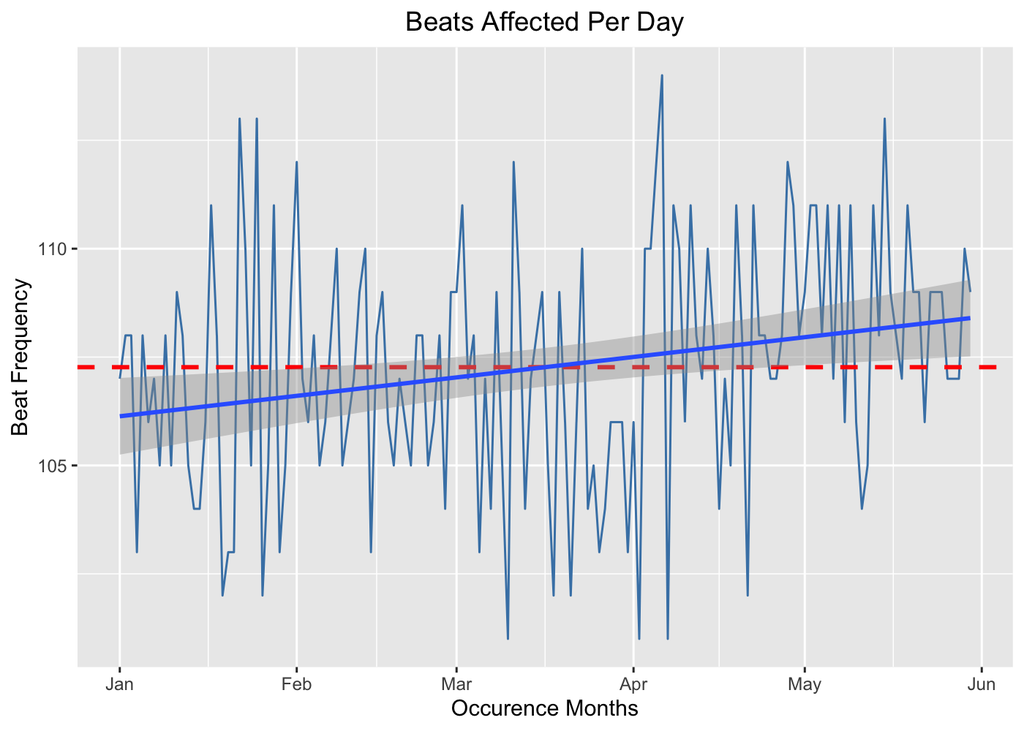

```r
# Select Occurrence Data and offense count Group by date
beat_dist <-
  crime_data %>% dplyr::select(occurrence_date, beat) %>% group_by(occurrence_date, beat) %>%
  summarise(CountOfBeat = unique(length(beat))) %>% group_by(occurrence_date) %>% summarise(CountOfBeat = length(CountOfBeat))


# Plot a time series graph showing the distribution of offenses over 5 months period
ggplot(beat_dist,
       aes(x = beat_dist$occurrence_date, y = beat_dist$CountOfBeat)) +
  geom_line(color = "steelblue") +
  geom_hline(
    aes(yintercept = mean(beat_dist$CountOfBeat)),
    color = "red",
    linetype = "dashed",
    size = 1
  ) +
  geom_smooth(method = 'lm') +
  theme(legend.position = "none",
        plot.title = element_text(hjust = 0.5)) +
  scale_color_brewer(palette = "Paired") +
  labs(title = "Beats Affected Per Day", x = "Occurence Months", y = "Beat Frequency")
```

- On an average there are 107 beats affected with crime everyday out of the 126 beats.
- On Apr 6th, there were 114 beats which were affected with crime.

### 4.2.7 Top 10 crimes month over month

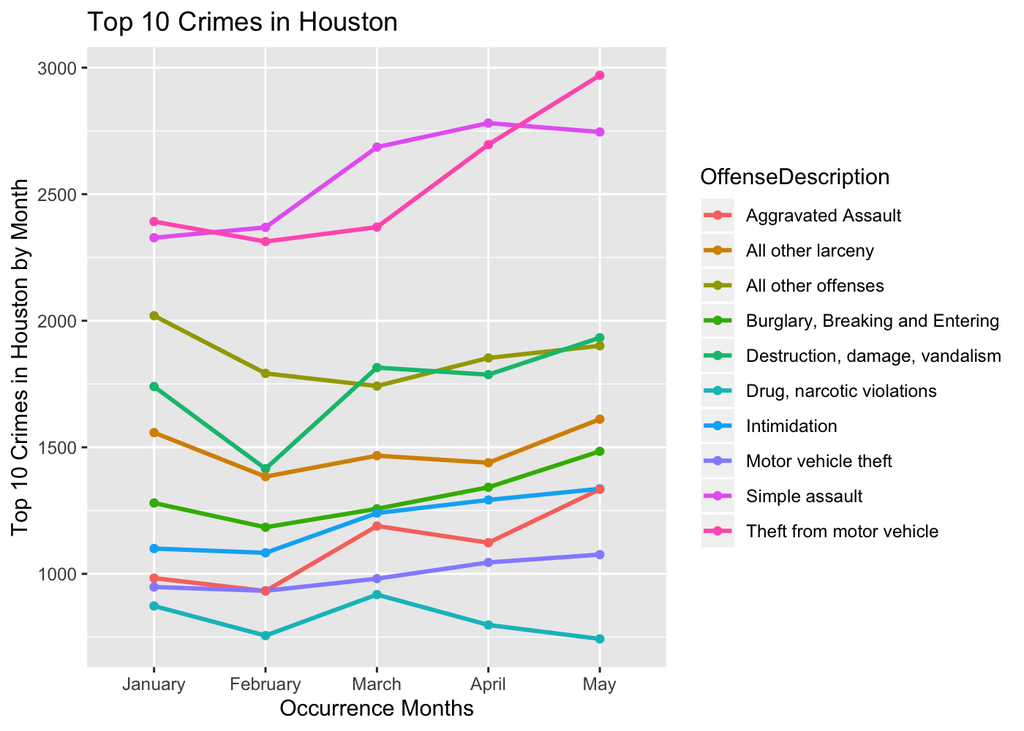

```r
# Filter the top 10 offenses descriptions
top.10.crimes.by.month_temp <-
  crime_data %>% dplyr::select(occurrence_date, nibrs_description, offense_count) %>% filter(
    crime_data$nibrs_description %in% c(
      "Simple assault",
      "Theft from motor vehicle",
      "All other offenses",
      "Destruction, damage, vandalism",
      "All other larceny",
      "Burglary, Breaking and Entering",
      "Intimidation",
      "Aggravated Assault",
      "Motor vehicle theft",
      "Drug, narcotic violations"
    )
  )

# Group by month and offenses description
top.10.crimes.by.month <- group_by(
  top.10.crimes.by.month_temp,
  OccurenceMonths = format(occurrence_date, "%B"),
  OffenseDescription = nibrs_description
) %>%  dplyr::summarize(Count = sum(offense_count)) %>% arrange(desc(Count))

# Plot a line graph
ggplot(data = top.10.crimes.by.month,
       aes(
         x = factor(OccurenceMonths, levels = month.name),
         y = Count,
         color = OffenseDescription,
         group = OffenseDescription
       )) +
  geom_line(size = 1) +
  geom_point() +
  scale_fill_brewer(palette = "Dark2") +
  labs(title = "Top 10 Crimes in Houston",
       x = "Occurrence Months",
       y = "Top 10 Crimes in Houston by Month") +
  guides(fill = guide_legend(reverse = TRUE, title = "Offense Description"))
```

### 4.2.8 Top 10 crimes in the most unsafe beats

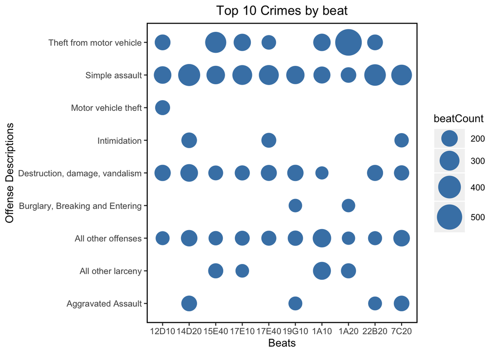

```r
# Filter the top 10 assaults from Crime data
top_crimes_beats_temp <-
  crime_data %>% dplyr::select(nibrs_description, beat, offense_count) %>% filter(
    crime_data$nibrs_description %in% c(
      "Simple assault",
      "Theft from motor vehicle",
      "All other offenses",
      "Destruction, damage, vandalism",
      "All other larceny",
      "Burglary, Breaking and Entering",
      "Intimidation",
      "Aggravated Assault",
      "Motor vehicle theft",
      "Drug, narcotic violations"
    )
  )

# Group by beat and offense description
top_crimes_beats <-
  group_by(top_crimes_beats_temp,
           beat, nibrs_description) %>%  dplyr::summarize(beatCount = sum(offense_count)) %>%
  arrange(desc(beatCount), nibrs_description) %>% top_n(5)

# Filter the top 10 Beats with high crime
top_crimes_beats <-  dplyr::filter(
             top_crimes_beats,
             as.character(beat) %in% c(
               "17E10",
               "14D20",
               "15E40",
               "22B20",
               "19G10",
               "1A10",
               "17E40",
               "12D10",
               "1A20",
               "7C20"
             )
           )

# Plot a ballon chart
p <- ggplot(top_crimes_beats, aes(x = beat, y = nibrs_description))
p + geom_point(
  aes(size = beatCount),
  shape = 21,
  colour = "steelblue",
  fill = "steelblue"
) +
  theme(plot.title = element_text(hjust = 0.5),
    panel.background = element_blank(),

    panel.border = element_rect(
      colour = "black",
      fill = NA,
      size = 1
    )
  ) +
  scale_size_area(max_size = 12) +
  labs(title = "Top 10 Crimes by beat", x = "Beats", y = "Offense Descriptions")
```

### 4.2.9 Who/What are most affected by these crimes?

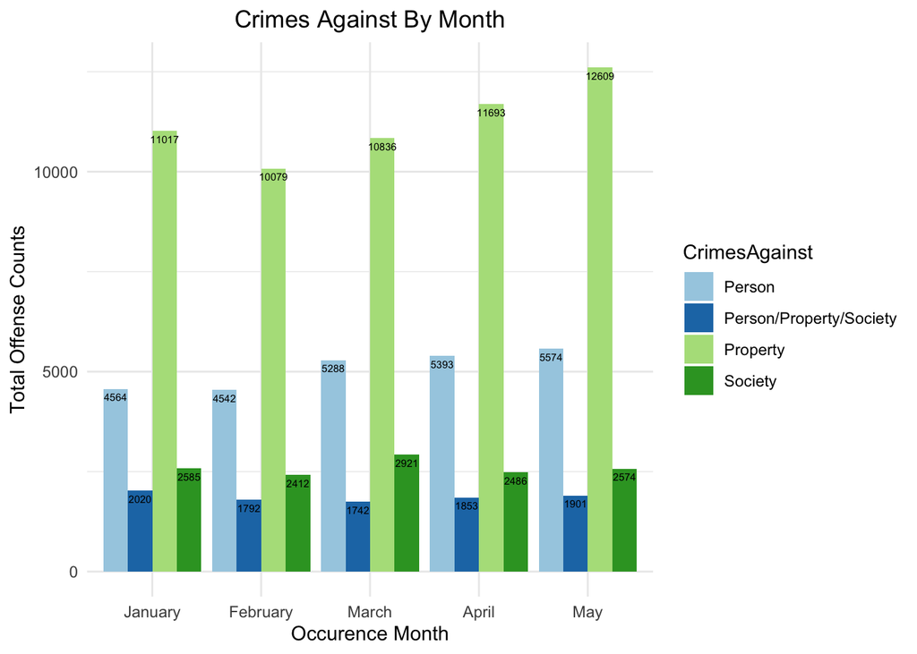

```r
# Group by crime against and month
top_crimes_against <-
  crime_data %>% dplyr::select(crime_against, occurrence_month, offense_count) %>%
  group_by(
    CrimesAgainst = crime_against,
    OccurenceMonths = format(crime_data$occurrence_date, "%B")
  ) %>%  dplyr::summarize(Count = sum(offense_count))

# Remove irrelavent crimes which are not so significant or explainable
top_crimes_against <-
  top_crimes_against[!(top_crimes_against$CrimesAgainst %in% c("NA", "Person/Not a Crime", "Not a Crime")),]

# Create a grouped bar plot
ggplot(data = top_crimes_against, aes(
  x = factor(OccurenceMonths, levels = month.name),
  y = Count,
  fill = CrimesAgainst
)) +
  geom_bar(stat = "identity", position = position_dodge()) +
  geom_text(
    aes(label = Count),
    vjust = 1.6,
    color = "black",
    position = position_dodge(0.9),
    size = 2
  ) +
  labs(title = "Crimes Against By Month",
       x = "Occurence Month", y = "Total Offense Counts") +
  scale_fill_brewer(palette = "Paired") +
  theme_minimal() + theme(plot.title = element_text(hjust = 0.5))
```

- Crime against person and property have been steady increasing since March.
- Societal crimes are on control.

### 4.2.10 Most unsafe streets in the worst beats

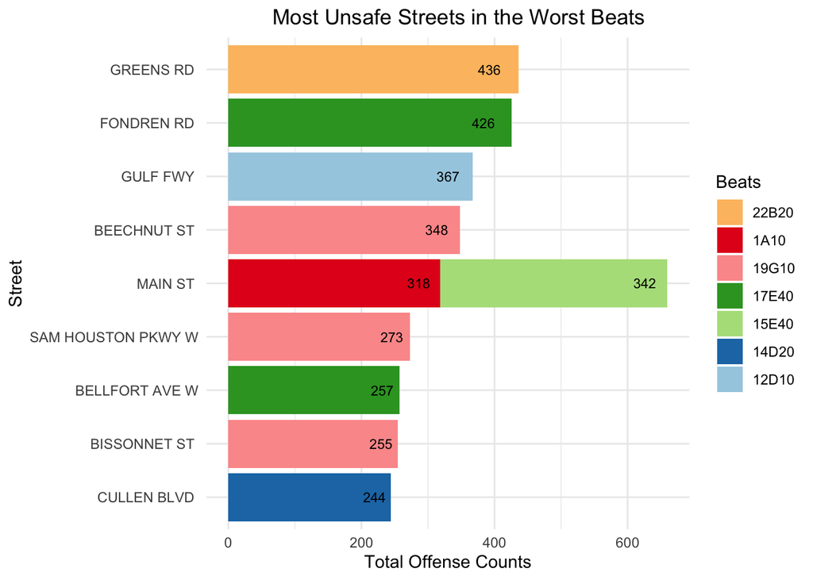

```r
# Group by crime against and month

top_streets_temp <-
  crime_data %>% dplyr::select(beat, street_name, street_type, suffix, offense_count) %>% dplyr::filter(
    as.character(beat) %in% c(
      "17E10",
      "14D20",
      "15E40",
      "22B20",
      "19G10",
      "1A10",
      "17E40",
      "12D10",
      "1A20",
      "7C20"
    )
  )

top_streets <-
  top_streets_temp %>%  group_by(beat, Street = paste(street_name, street_type, replace(suffix, is.na(suffix), ""), sep = " ")) %>%  dplyr::summarize(Count = sum(offense_count)) %>% arrange(desc(Count)) %>% head(10)

ggplot(top_streets, aes(
  x = reorder(Street, Count),
  y = Count,
  fill = beat,
  label = Count
)) +
  geom_bar(stat = "identity") +
  geom_text(
    vjust = 0.5,
    color = "black",
    position = position_stack(vjust = 0.9),
    size = 3
  ) +
  labs(title = "Most Unsafe Streets in the Worst Beats",
       x = "Street", y = "Total Offense Counts") +
  scale_fill_brewer(palette = "Paired") +
  theme_minimal() +
  theme(plot.title = element_text(hjust = 0.6)) +
  coord_flip() +
  guides(fill = guide_legend(reverse = TRUE, title = "Beats"))
```

- Main Street which runs from 1A10 through 15E40 beats is the risky road to travel.
- Greens Road in 22B20 has the highest number of incidents.

### 4.2.11 Average crimes by beat month over month

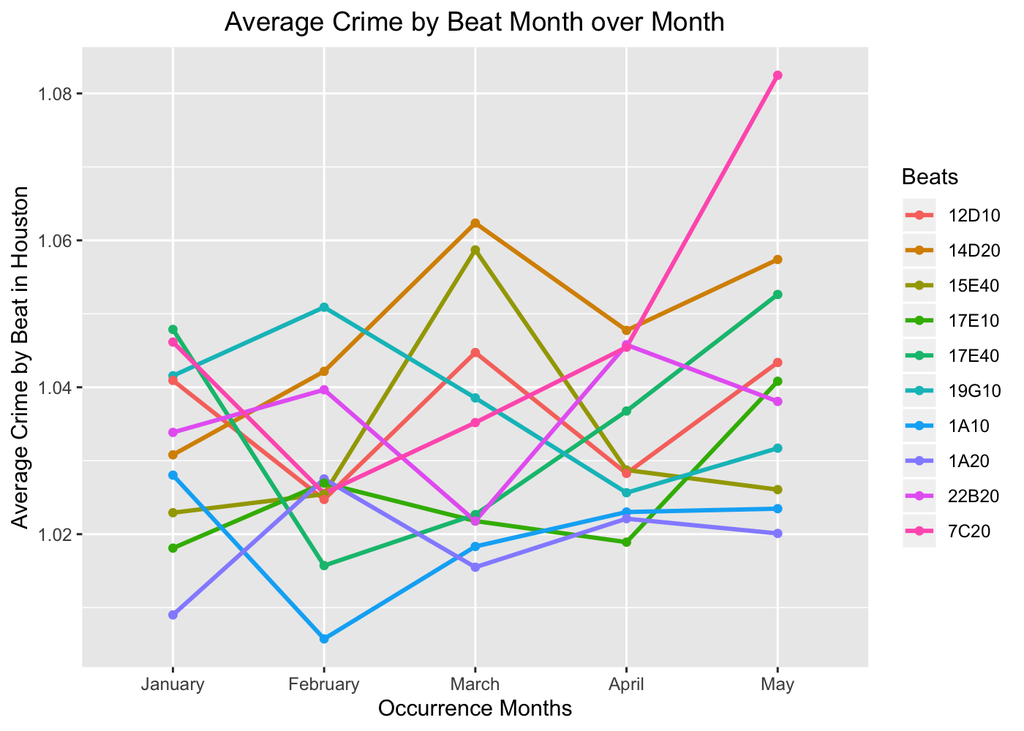

```r
top_beats_avg_temp <-
  crime_data %>% dplyr::select(occurrence_date, beat, offense_count) %>% dplyr::filter(
    as.character(beat) %in% c(
      "17E10",
      "14D20",
      "15E40",
      "22B20",
      "19G10",
      "1A10",
      "17E40",
      "12D10",
      "1A20",
      "7C20"
    )
  )

# Group by month and offenses description
top_beats_avg <- group_by(
  top_beats_avg_temp,
  OccurenceMonths = format(occurrence_date, "%B"),
  Beats = beat
) %>%  dplyr::summarize(Count = mean(offense_count)) %>% arrange(desc(Count))


# Plot a line graph
ggplot(data = top_beats_avg,
       aes(
         x = factor(OccurenceMonths, levels = month.name),
         y = Count,
         color = Beats,
         group = Beats
       )) +
  geom_line(size = 1) +
  geom_point() +
  scale_fill_brewer(palette = "Dark2") +
  labs(title = "Average Crime by Beat Month over Month",
       x = "Occurrence Months",
       y = "Average Crime by Beat in Houston") +
  guides(fill = guide_legend(reverse = TRUE, title = "Beats")) +
  theme(plot.title = element_text(hjust = 0.5))
```

### 4.2.12 Unique zip codes on a map

```r
bounds <- map('state', c('Texas'), fill=TRUE, plot=FALSE)
icons <- awesomeIcons(
    icon = 'disc',
    iconColor = 'black',
    library = 'ion', # Options are 'glyphicon', 'fa', 'ion'.
    markerColor = 'blue',
    squareMarker = TRUE
)

crime_data_map <- crime_data %>% dplyr::select(zip, latitude, longitude) %>% distinct

maxLong = max(crime_data_map$longitude)
maxLat = max(crime_data_map$latitude)
minLong = min(crime_data_map$longitude)
minLat = min(crime_data_map$latitude)

# Create the Leaflet map widget and add some map layers.
# We use the pipe operator %>% to streamline the adding of
# layers to the leaflet object. The pipe operator comes from
# the magrittr package via the dplyr package.
leaflet(data = crime_data_map) %>%
  setView(zoom = 100, lat = 29.10, lng = -95.10) %>%
  addProviderTiles("CartoDB.Positron", group = "Map") %>%
  addProviderTiles("Esri.WorldImagery", group = "Satellite") %>%
  addProviderTiles("Esri.WorldShadedRelief", group = "Relief") %>%
  # Marker data are from the sites data frame. We need the ~ symbols
  # to indicate the columns of the data frame.
  addMarkers(
    ~ longitude,
    ~ latitude,
    label = ~ zip,
    group = "Sites",
    icon = icons
  ) %>%
  addPolygons(
    data = bounds,
    group = "States",
    weight = 2,
    fillOpacity = 0
  ) %>%
  addScaleBar(position = "bottomleft") %>%
  addLayersControl(
    baseGroups = c("Map", "Satellite", "Relief"),
    overlayGroups = c("Sites", "States"),
    options = layersControlOptions(collapsed = FALSE)
  ) %>% fitBounds(minLong, minLat, maxLong, maxLat)
```

[interactive chart not shown]

- Mapping the zip codes on a Map informs few interesting things about data. There are offenses in the data set which with have happened outside of the HPD jurisdiction or may be an error in the entry of the data. Zip code 78728 is very close to Austin, TX and has an entry in the data set under 8C10 beat.
- Same could be the case with Zip code 77541 which seems to be too far away from Houston.

### 4.2.13 Heatmap of offenses in Houston

```r
# Group by zipcode and sum of offense counts
heatmap.by.zipcode <-
  crime_data %>% dplyr::select(zip, latitude, longitude,offense_count) %>%
  group_by(
    zip,
    latitude,
    longitude
  ) %>%  dplyr::summarize(Count = sum(offense_count)) %>%
  arrange(desc(Count))

# add a dark matter map and display the intensity
leaflet(quakes) %>% addProviderTiles(providers$CartoDB.DarkMatter) %>%
  setView(zoom = 9.5, lat = 29.79, lng = -95.35) %>%
  addHeatmap(
    lng = ~ heatmap.by.zipcode$longitude,
    lat = ~ heatmap.by.zipcode$latitude,
    intensity = ~ mag,
    blur = 20,
    max = 0.05,
    radius = 15
  )
```

[interactive chart not shown]

- Highest intensity of crimes happening in the city center of Houston.

### 4.2.14 Crimes and zipcodes on map

**NOTE:** Hover over the circles to see the zipcode and count of offenses in that zipcode

```r
# Group by zipcode
crimes.by.zipcode <-
  crime_data %>% dplyr::select(zip, latitude, longitude, offense_count) %>%
  group_by(zip,
           latitude,
           longitude) %>%  dplyr::summarize(Count = sum(offense_count)) %>%
  arrange(desc(Count))

# Set color scheme
color_scheme <-
  viridis::cividis(n_distinct(crimes.by.zipcode$zip))
pal = colorFactor(color_scheme, crimes.by.zipcode$zip)

# Plot data on a map
crimes.by.zipcode %>%
  leaflet() %>%
  setView(zoom = 10.5,
          lat = 29.79,
          lng = -95.35) %>%
  addProviderTiles(providers$CartoDB.Positron) %>%
  addCircleMarkers(
    ~ as.numeric(longitude),
    ~ as.numeric(latitude),
    weight = 1,
    radius = ~ sqrt(Count) * 0.7,
    label = ~htmlEscape(paste(
      paste("Zip = ", as.character(zip), sep = " "),
      paste("Count = ", as.character(Count), sep = " "),
      sep = ", "
    ))) %>%
  addHeatmap(
    lng =  ~ as.numeric(longitude),
    lat =  ~ as.numeric(latitude),
    blur = 20,
    max = 0.05,
    radius = 15
  )
```

[interactive chart not shown]

- Zip code 77004 at the heart of the city is the most unsafe zip code.
- Higher the population more the number of offenses is clearly noticeable from this map as there are fewer crimes in the Houston suburbs compared to city center.